# Urban Data Science Lab - day 5 - intrinsic data quality

Sven Lautenbach

10/21/2020

A helper function that eases the communication with the API a bit. It handles the processing of the data to ensure that a properly formated data.frame is returned.

```r
getOsomeStat <- function(uri, valueFieldName="value", ...)
{
  results <- postForm(uri, binary=FALSE, .encoding = "utf-8", ...)

  #browser()
  resultList <- RJSONIO::fromJSON(results, simplify = TRUE)
  resultsDf <- data.frame(do.call("rbind", (resultList$result)))
  # make sure the right data types are used
  # for users we have  fromTimestamp  and  toTimestamp fields, not timestampe
  if(length(grep(x=names(resultsDf), pattern = "timestamp"))> 0)
  {
    resultsDf$timestamp <- parse_datetime( as.character(resultsDf$timestamp))
  }
  if(length(grep(x=names(resultsDf), pattern = "fromTimestamp"))> 0)
  {
    resultsDf$fromTimestamp <- parse_datetime( as.character(resultsDf$fromTimestamp))
  }
  if(length(grep(x=names(resultsDf), pattern = "toTimestamp"))> 0)
  {
    resultsDf$toTimestamp <- parse_datetime( as.character(resultsDf$toTimestamp))
  }
  # rename value field
  resultsDf$value <- as.numeric(as.character(resultsDf$value))
  idxValueField <- which(names(resultsDf)=="value")
  names(resultsDf)[idxValueField] <- valueFieldName


  return(resultsDf)
}
```

# 1 Intrinsic data quality for Lima

## 1.1 Highway

### 1.1.1 Get time series of contributions

To estimate how complete the OSM data are we could look at the historic development of OSM contributions.

```r
adminLimaCallao <- st_read(dsn="data_day5/lima.gpkg", layer="limaCallao")
limaBbox <- st_bbox(adminLimaCallao)
limaBboxStr <- paste(limaBbox, collapse = ", ")
```

For highways we query the development of road length over time

```r
theTime <- "2008-01-01/2020-05-01/P1M"
theTimeUser <- "2007-12-01/2020-05-01/P1M"
```

```r
resHighwayTotal <- getOsomeStat(uri = "https://api.ohsome.org/v1/elements/length/", bboxes = limaBboxStr, filter = "highway=* and type:way", time = theTime, valueFieldName = "highway_length_total")
```

Lets get also separate information for primary, secundary and tertiary roads as well as for residential roads

```r
resHighwayPrimary <- getOsomeStat(uri = "https://api.ohsome.org/v1/elements/length/", bboxes = limaBboxStr, filter = "highway=primary and type:way", time = theTime, valueFieldName = "highwayPrimary_length_total")

resHighwaySecondary <- getOsomeStat(uri = "https://api.ohsome.org/v1/elements/length/", bboxes = limaBboxStr, filter = "highway=secondary and type:way", time = theTime, valueFieldName = "highwaySecondary_length_total")

resHighwayTertiary <- getOsomeStat(uri = "https://api.ohsome.org/v1/elements/length/", bboxes = limaBboxStr, filter = "highway=tertiary and type:way", time = theTime, valueFieldName = "highwayTertiary_length_total")

resHighwayResidential <- getOsomeStat(uri = "https://api.ohsome.org/v1/elements/length/", bboxes = limaBboxStr, filter = "highway=residential and type:way", time = theTime, valueFieldName = "highwayResidential_length_total")
```

Combine the data.frames - they all have the same order since time is exactly the same:

```r
resHighwayTs <- cbind(resHighwayTotal,
                      resHighwayPrimary$highwayPrimary_length_total,
             resHighwaySecondary$highwaySecondary_length_total,
             resHighwayTertiary$highwayTertiary_length_total,
             resHighwayResidential$highwayResidential_length_total)
names(resHighwayTs) <- c("timestamp", "total_highway_length", "primary_highway_length", "secondary_highway_length", "tertiary_highway_length", "residential_highway_length")
```

For routing application it is important that the road network is relative complete. Therefore, we will be adding up the four main road types (excluding motorways and trunks for right now):

```r
resHighwayTs$roadLength4cls <- resHighwayTs %>% select(3:6) %>% rowSums(na.rm=TRUE)
```

### 1.1.2 Plot highway contributions

First we are going to change the table format from the wide format to the long format since this simplyfies handling in ggplot dramatically.

```r
resHighwayTs_long <- pivot_longer(resHighwayTs, 2:7, names_to = "type", values_to = "length" )
resHighwayTs_long$length <- resHighwayTs_long$length / 1000 # konvert to km
```

Reorder the factor levels for nicer plotting

```r
resHighwayTs_long$type <- factor(resHighwayTs_long$type, levels = c("total_highway_length", "primary_highway_length", "secondary_highway_length", "tertiary_highway_length", "residential_highway_length", "roadLength4cls"))
```

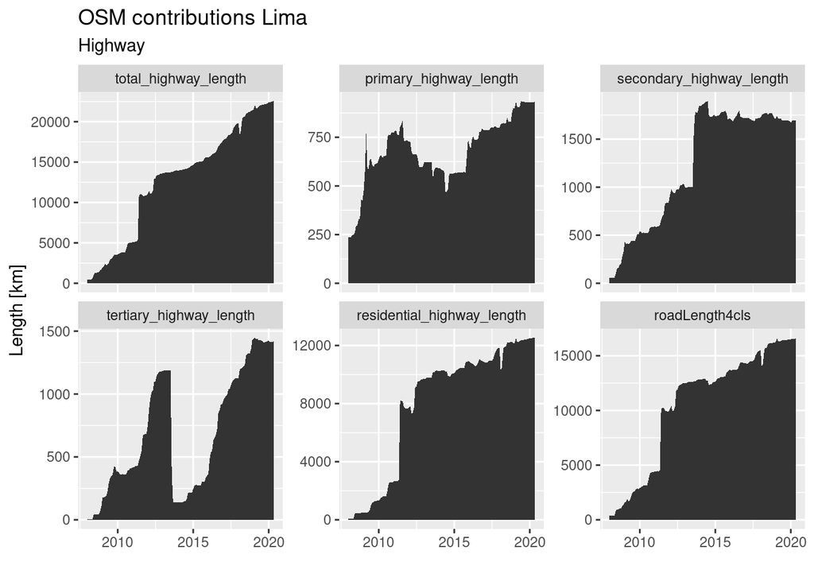

```r
ggplot(resHighwayTs_long, mapping=aes(x=timestamp, y=length)) + geom_area() + facet_wrap(facets = vars(type), scales="free_y") + xlab("") + ylab("Length [km]") + labs(title = "OSM contributions Lima", subtitle = "Highway")
```

We see that the growth of total length of the road network still continues to increase. However, the slope has decreased - the process might not have levelled of but it might have already started to level of. We also observe a strong jump of total highway length at around 2012 which presumably was caused by an import.

We also observe that inbetween the road length for tertiary highways dropped drastically and that primary highways decreased between 2012 and 2015. Potentially these might be do to a reclassification of highways. This might become clearer if the stack the different components.

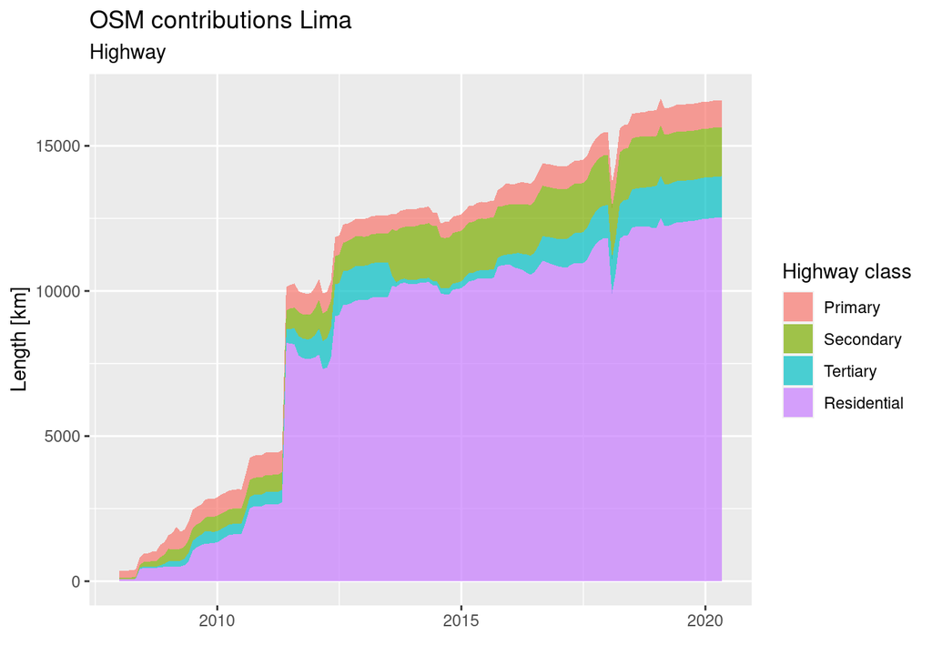

```r
resHighwayTs_long %>%
  filter(type != "total_highway_length" & type != "roadLength4cls") %>%
  ggplot( mapping=aes(x=timestamp, y=length, fill=type)) +
  geom_area(position="stack", show.legend = TRUE, alpha=.7) +
  scale_fill_discrete(name = "Highway class",
                      labels = c("Primary", "Secondary", "Tertiary", "Residential")) +
  xlab("") + ylab("Length [km]") +
  labs(title = "OSM contributions Lima", subtitle = "Highway")
```

### 1.1.3 Fit saturation curve for total highway length

#### 1.1.3.1 Logistic curve

We could try to fit a saturation curve (logistic curve in this example) to the data to estimat how well it fits the data.

We use a parametrization of the logistic function for which a selt-starter functions exists:

$y = \frac{Asym} {1+e^{\frac{x_{mid} - x}{scal}}}$

- $Asym$ is the asymptotic value the function converges against
- $x_{mid}$ is the x-value (here time, in seconds since 01.01.1970) at which the curve has its turing point (half saturation point)
- $scal is inversely related to the slope of the curve

For the fitting of non-linear functions we need to provide suitable start values for all parameters to be estimated. Otherwise the function might not converge. For some commonly used function R provides self-starter functions, that estimate suitable start values from the data.

```r
g <- nls(length ~ SSlogis(input=as.numeric(timestamp), Asym, xmid, scal), data = resHighwayTs_long, subset= type == "total_highway_length")
summary(g)
```

```
##
## Formula: length ~ SSlogis(input = as.numeric(timestamp), Asym, xmid, scal)
##
## Parameters:
##       Estimate Std. Error t value Pr(>|t|)
## Asym 2.154e+04  4.391e+02   49.06   <2e-16 ***
## xmid 1.350e+09  4.526e+06  298.26   <2e-16 ***
## scal 6.767e+07  3.697e+06   18.30   <2e-16 ***
## ---
## Signif. codes:  0 '***' 0.001 '**' 0.01 '*' 0.05 '.' 0.1 ' ' 1
##
## Residual standard error: 1594 on 146 degrees of freedom
##
## Number of iterations to convergence: 0
## Achieved convergence tolerance: 1.542e-06
```

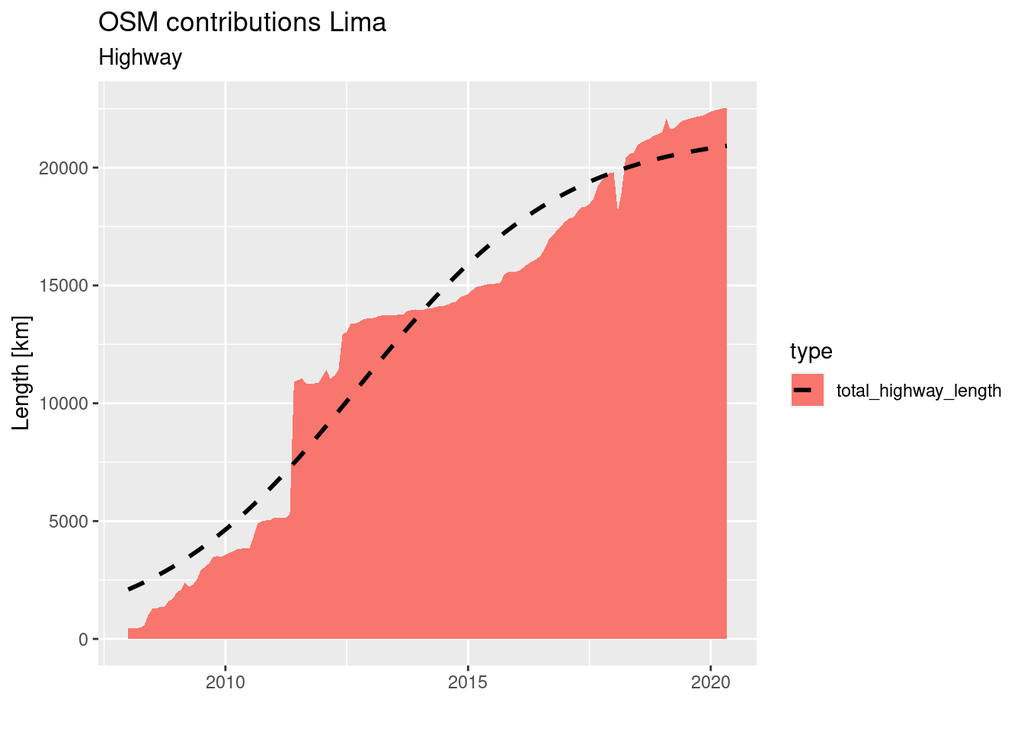

```r
resHighwayTs_long %>%
  filter(type == "total_highway_length") %>%
  ggplot( mapping=aes(x=timestamp, y=length, fill=type)) +
  geom_area() +
  xlab("") + ylab("Length [km]") +
  labs(title = "OSM contributions Lima", subtitle = "Highway") +
geom_smooth( method="nls", formula= y~ SSlogis(input=x, Asym, xmid, scal) , se=FALSE, col="black", lty=2, size=1)
```

The single saturation curve does not fit to well. A double logistic curve presumably fits the data better.

#### 1.1.3.2 Double logistic curve

The double logistic curve is the sum of two logist curves therebey the second curve is zero until a threshold. It can be expressed as follows:

$$y= \frac{a_1} {1+ e^{k_1*( b_1- x)}} + \frac{a_2-a_1} {1+ e^{k_2*( b_2- x)}}$$

For the double logistic curve we have no self-starter function. Which implies that we have to supply start values for the function.

```r
doubleLog <- function(x, a1, a2, b1, b2, k1, k2)
{
  y <- a1 / (1+ exp(k1*( b1- x))) + (a2-a1) / (1+ exp(k2*( b2- x)))
  res <- data.frame(y, x=as.Date.POSIXct(x))

  return(res)
}
doubleLog(x=1525125600, a1= 6000, a2=2500, k1=10^6, k2=10^6, b1=as.numeric(as.POSIXct("2015-01-01")), b2= as.numeric(as.POSIXct("2018-05-01")))
```

```
## # A tibble: 1 x 2
##       y x
##   <dbl> <date>
## 1  4250 2018-04-30
```

Lets plot the function for different parameters. First varying a1 and a2:

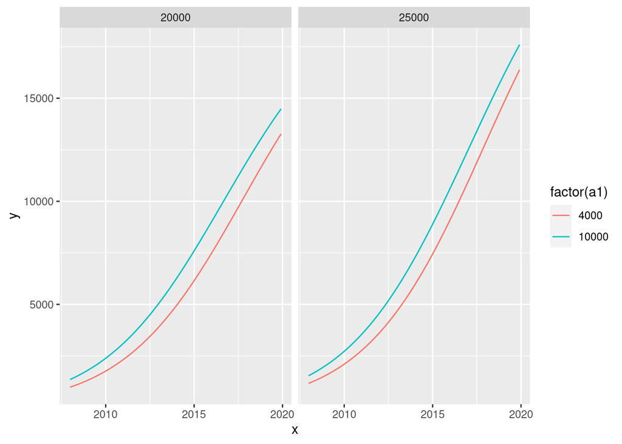

```r
xstart <- as.numeric(as.POSIXct("2008-01-01"))
xend <- as.numeric(as.POSIXct("2019-12-01"))

params <- crossing(a1 = c(4000, 10000), a2 = c(25000, 20000), k1=10^-8, k2=10^-8, b1=as.numeric(as.POSIXct("2015-01-01")), b2= as.numeric(as.POSIXct("2018-05-01")))

params %>%
  dplyr::mutate(res=purrr::pmap(., .f = doubleLog,  x = seq(xstart, xend, by=10^4))) %>%
  tidyr::unnest(cols=c(res)) %>%
  ggplot(aes(x=x, y=y, colour=factor(a1)))+
    facet_wrap(~a2, ncol=2) + geom_line()
```

Changing the slope coefficients:

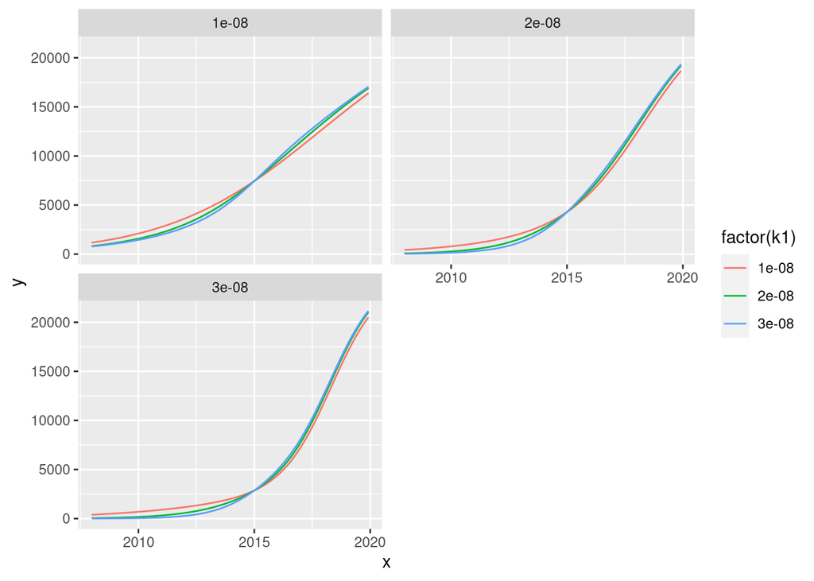

```r
params <- crossing(a1 = 4000, a2 = 25000, k1=c((1:3)*10^-8), k2=(1:3)*10^-8, b1=as.numeric(as.POSIXct("2015-01-01")), b2= as.numeric(as.POSIXct("2018-05-01")))

params %>%
  dplyr::mutate(res=purrr::pmap(., .f = doubleLog,  x = seq(xstart, xend, by=10^4))) %>%
  tidyr::unnest(cols=c(res)) %>%
  ggplot(aes(x=x, y=y, colour=factor(k1)))+
    facet_wrap(~k2, ncol=2) + geom_line()
```

Changing the half-saturation coefficients. For a niver labelling I define a labeller function that converts the number of seconds into a date string. The labbeler is called for each facet and should put the returned labels in the facet title.

```r
convStr2Date <- function(str)
{ # adding a day is necessary to get the right Date, not interley clear why...
  return(as.character(as.Date.POSIXct(as.numeric(as.character(str))+3600*24)))
}

label_time <- function(timeLabels, multi_line = TRUE){
  #browser()
  value <- label_value(timeLabels, multi_line = multi_line)
  labels <- lapply(value, convStr2Date)
  if (!multi_line) {
        labels <- collapse_labels_lines(labels)
  }
   return(labels)
}
```

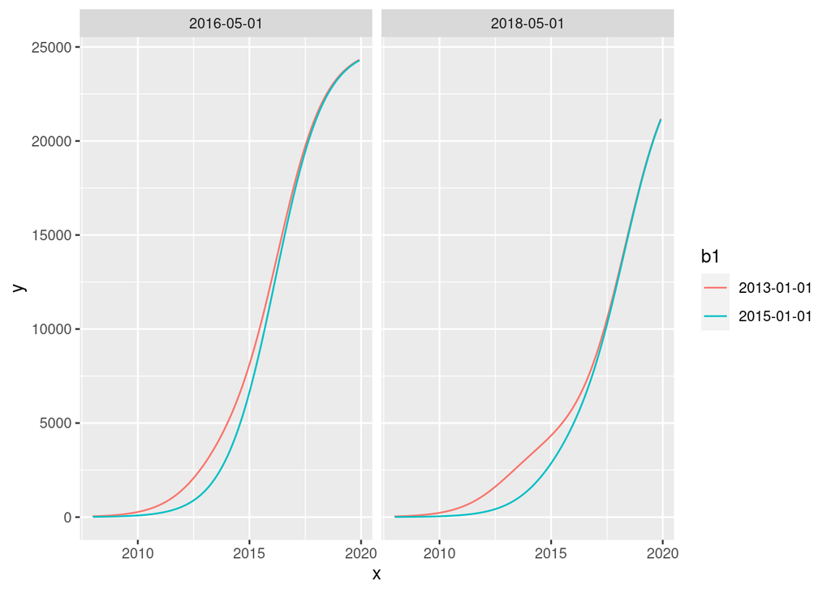

```r
params <- crossing(a1 = 4000, a2 = 25000, k1=3*10^-8, k2=3*10^-8, b1=as.numeric(as.POSIXct(c("2013-01-01", "2015-01-01"))), b2= as.numeric(as.POSIXct(c("2016-05-01","2018-05-01"))))

theDf <- params %>%
  dplyr::mutate(res=purrr::pmap(., .f = doubleLog,  x = seq(xstart, xend, by=10^4))) %>%
  tidyr::unnest(cols=c(res))

theDf %>% ggplot(aes(x=x, y=y, colour=factor(b1)))+
    facet_wrap(~b2 , ncol=2, labeller = labeller(b2 = label_time ) ) +
  geom_line() +
  scale_color_discrete(name = "b1",
                      labels = convStr2Date(unique(theDf$b1)))
```

Now we fit the non-linear function using *nls* providing a set of start values for the 6 parameters. If these values are not well chosen the function will not converge.

```r
g <- nls(length ~  a1 / (1+ exp(k1*( b1- as.numeric(timestamp)))) + (a2-a1) / (1+ exp(k2*( b2- as.numeric(timestamp)))),
         data = resHighwayTs_long, subset= type == "total_highway_length",
         start=c(a1=6000, a2= 25000, k1=10^-6, k2=10^-6, b1=as.numeric(as.POSIXct("2015-01-01")), b2= as.numeric(as.POSIXct("2018-05-01"))))
summary(g)
```

```
##
## Formula: length ~ a1/(1 + exp(k1 * (b1 - as.numeric(timestamp)))) + (a2 -
##     a1)/(1 + exp(k2 * (b2 - as.numeric(timestamp))))
##
## Parameters:
##     Estimate Std. Error t value Pr(>|t|)
## a1 1.471e+04  2.579e+02  57.027  < 2e-16 ***
## a2 2.270e+04  3.549e+02  63.959  < 2e-16 ***
## k1 3.611e-08  1.679e-09  21.501  < 2e-16 ***
## k2 3.907e-08  5.369e-09   7.278 2.07e-11 ***
## b1 1.298e+09  1.695e+06 765.860  < 2e-16 ***
## b2 1.501e+09  3.532e+06 424.905  < 2e-16 ***
## ---
## Signif. codes:  0 '***' 0.001 '**' 0.01 '*' 0.05 '.' 0.1 ' ' 1
##
## Residual standard error: 724.7 on 143 degrees of freedom
##
## Number of iterations to convergence: 23
## Achieved convergence tolerance: 4.814e-06
```

```r
idx_a1 <- which(names(coef(g))=="a1")
idx_a2 <- which(names(coef(g))=="a2")
saturationCoef <- as.numeric(coef(g)[idx_a1] + coef(g)[idx_a2])

maxVal <- resHighwayTs_long %>%
  filter(type == "total_highway_length") %>% select(length) %>% max()
```

Which dates have been selected?

```r
idx_b1 <- which(names(coef(g))=="b1")
as.Date.POSIXct(coef(g)[idx_b1])
```

```
##           b1
## "2011-02-18"
```

```r
idx_b2 <- which(names(coef(g))=="b2")
as.Date.POSIXct(coef(g)[idx_b2])
```

```
##           b2
## "2017-07-22"
```

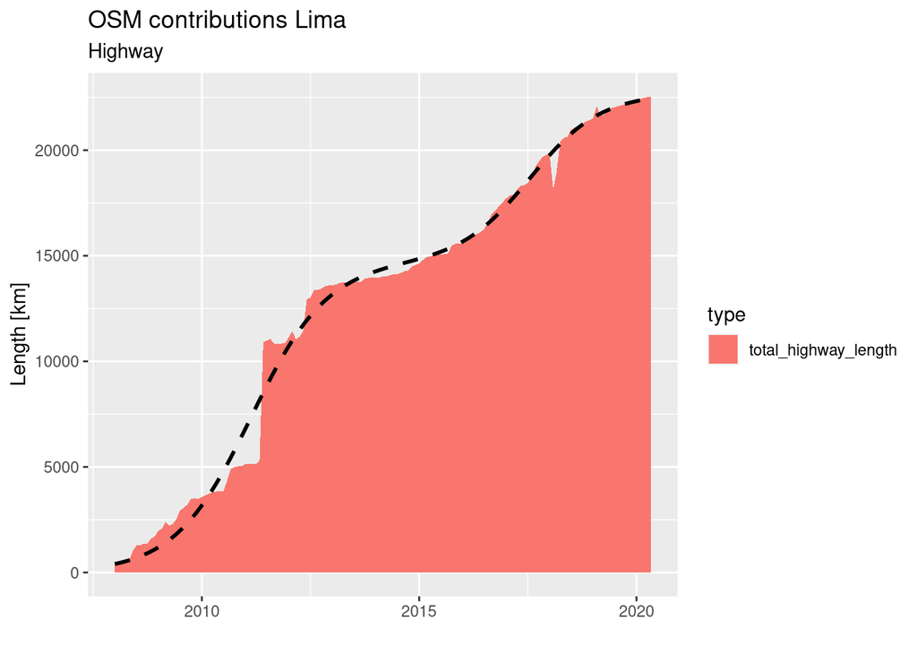

```r
resHighwayTs_long %>%
  filter(type == "total_highway_length") %>%
  ggplot( mapping=aes(x=timestamp, y=length, fill=type)) +
  geom_area() +
  xlab("") + ylab("Length [km]") +
  labs(title = "OSM contributions Lima", subtitle = "Highway") +
geom_smooth( method="nls", formula= y~ a1 / (1+ exp(k1*( b1- x))) + (a2-a1) / (1+ exp(k2*( b2- x))), method.args= list(start=c(a1=6000, a2= 25000, k1=10^-6, k2=10^-6, b1=as.numeric(as.POSIXct("2015-01-01")), b2= as.numeric(as.POSIXct("2018-05-01"))) )  , se=FALSE, col="black", lty=2, show.legend=FALSE)
```

In other words: the road network is presumably not yet complete. The primary roads seems also incomplete.

###Fit saturation curve for primary highway length

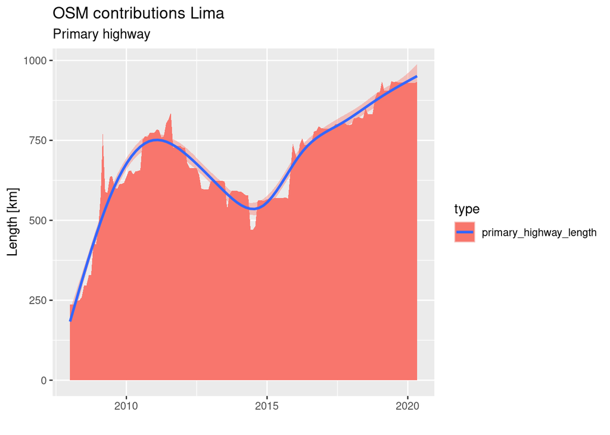

```r
resHighwayTs_long %>%
  filter(type == "primary_highway_length") %>%
  ggplot( mapping=aes(x=timestamp, y=length, fill=type)) +
  geom_area() +
  xlab("") + ylab("Length [km]") +
  labs(title = "OSM contributions Lima", subtitle = "Primary highway") +
geom_smooth( method="gam")
```

The time series can neither be fitted by a logistic nor a double logistic curve.

If we just look at the time after 2014 we are able to fit a logistic curve to the data that were created since when. This would indicate a relatively saturated situation. However, it is questionable if no further bumps would occur.

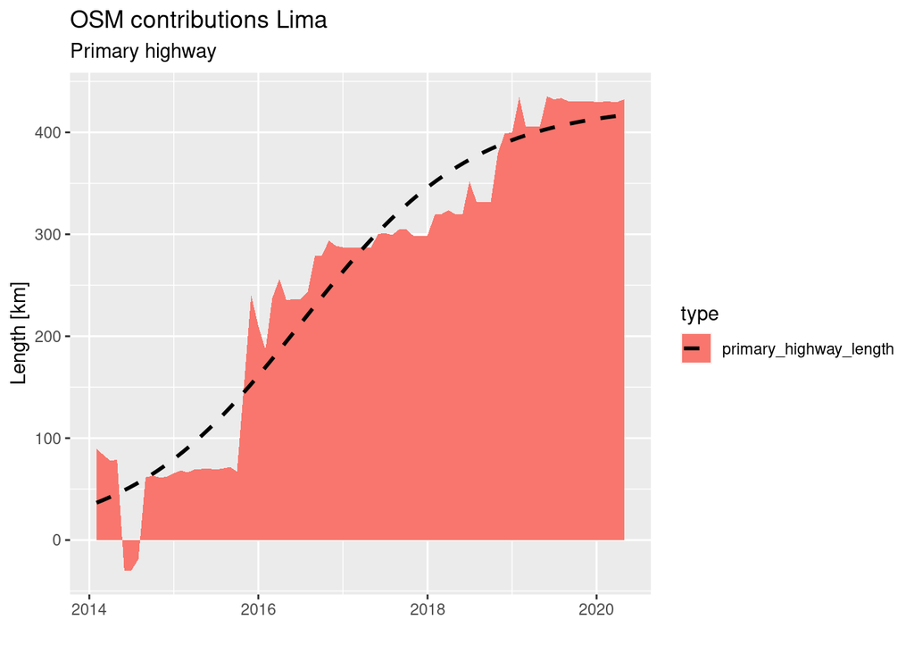

```r
resHighwayTs_long %>%
  filter(type == "primary_highway_length" & timestamp > as.Date("2014-01-01")) %>%
  ggplot( mapping=aes(x=timestamp, y=length-500, fill=type)) +
  geom_area() +
  xlab("") + ylab("Length [km]") +
  labs(title = "OSM contributions Lima", subtitle = "Primary highway") +
geom_smooth(method="nls", formula= y~ SSlogis(input=x, Asym, xmid, scal) , se=FALSE, col="black", lty=2, size=1)
```

If we look (not shown here) at an animation that shows the highway development for the region we see that the highway network seems relatively dense - but this does not imply that roads could not be wrongly labelled.

### 1.1.4 Fit saturation for combined road network

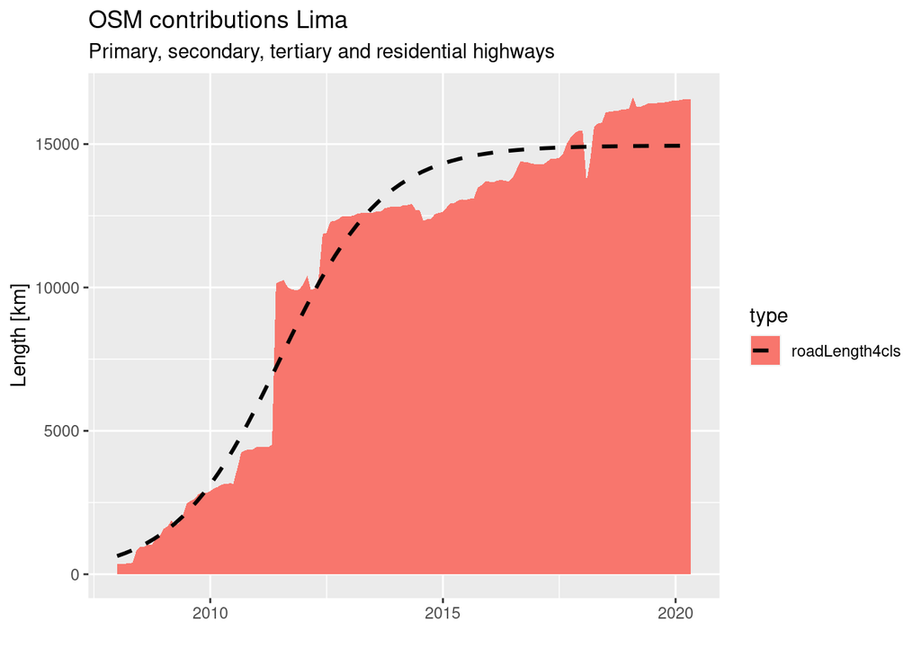

```r
resHighwayTs_long %>%
  filter(type == "roadLength4cls") %>%
  ggplot( mapping=aes(x=timestamp, y=length, fill=type)) +
  geom_area() +
  xlab("") + ylab("Length [km]") +
  labs(title = "OSM contributions Lima", subtitle = "Primary, secondary, tertiary and residential highways") +
geom_smooth( method="nls", formula= y~ SSlogis(input=x, Asym, xmid, scal) , se=FALSE, col="black", lty=2, size=1)
```

```r
g <- nls(length ~  a1 / (1+ exp(k1*( b1- as.numeric(timestamp)))) + (a2-a1) / (1+ exp(k2*( b2- as.numeric(timestamp)))),
         data = resHighwayTs_long, subset= type == "roadLength4cls",
         start=c(a1=6000, a2= 25000, k1=10^-6, k2=10^-6, b1=as.numeric(as.POSIXct("2015-01-01")), b2= as.numeric(as.POSIXct("2018-05-01"))))
summary(g)
```

```
##
## Formula: length ~ a1/(1 + exp(k1 * (b1 - as.numeric(timestamp)))) + (a2 -
##     a1)/(1 + exp(k2 * (b2 - as.numeric(timestamp))))
##
## Parameters:
##      Estimate Std. Error t value Pr(>|t|)
## a1  5.968e+02  4.029e+02   1.481    0.141
## a2  1.552e+04  4.166e+02  37.259   <2e-16 ***
## k1 -6.860e-07  3.887e-06  -0.176    0.860
## k2  2.997e-08  2.145e-09  13.969   <2e-16 ***
## b1  1.367e+09  9.465e+06 144.420   <2e-16 ***
## b2  1.315e+09  4.645e+06 283.188   <2e-16 ***
## ---
## Signif. codes:  0 '***' 0.001 '**' 0.01 '*' 0.05 '.' 0.1 ' ' 1
##
## Residual standard error: 1115 on 143 degrees of freedom
##
## Number of iterations to convergence: 31
## Achieved convergence tolerance: 5.367e-06
```

Plotting the resultng regression line

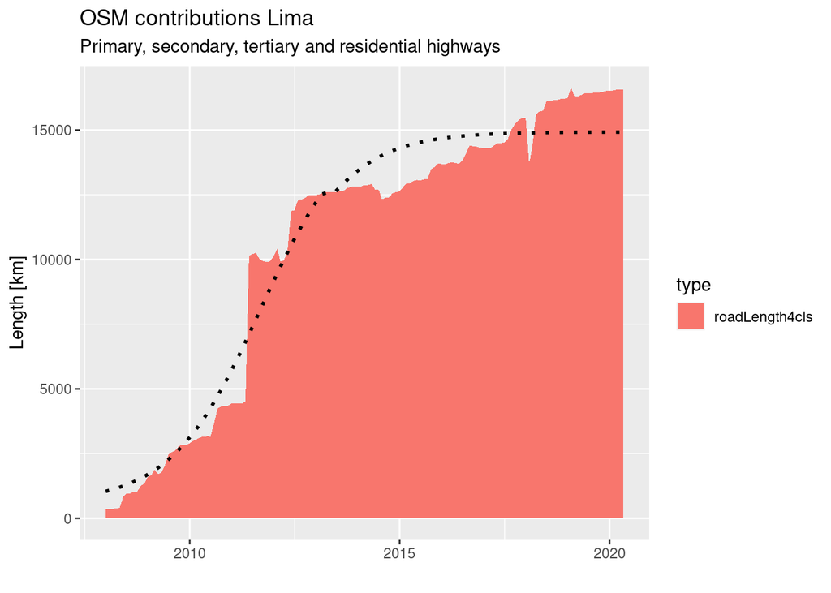

```r
resHighwayTs_long %>%
  filter(type == "roadLength4cls") %>%
  ggplot( mapping=aes(x=timestamp, y=length, fill=type)) +
  geom_area() +
  xlab("") + ylab("Length [km]") +
  labs(title = "OSM contributions Lima", subtitle = "Primary, secondary, tertiary and residential highways") +
geom_smooth( method="nls", formula= y~ a1 / (1+ exp(k1*( b1- x))) + (a2-a1) / (1+ exp(k2*( b2- x))), method.args= list(start=c(a1=6000, a2= 25000, k1=10^-6, k2=10^-6, b1=as.numeric(as.POSIXct("2015-01-01")), b2= as.numeric(as.POSIXct("2018-07-01"))) )  , se=FALSE, col="black", lty=2, show.legend=FALSE) +
geom_smooth( method="nls", formula= y~ a1 / (1+ exp(k1*( b1- x))) + (a2-a1) / (1+ exp(k2*( b2- x))), method.args= list(start=c(a1=6000, a2= 25000, k1=10^-6, k2=10^-6, b1=as.numeric(as.POSIXct("2015-01-01")), b2= as.numeric(as.POSIXct("2018-05-01"))) )  , se=FALSE, col="black", lty=3, show.legend=FALSE)
```

# 2 Healthsites

Here we use the count endpoint since we are interested in the number of healthsites - length would not make much sense here.

## 2.1 Get contributions from ohsome

```r
resHealthSitesTotal <- getOsomeStat(uri = "https://api.ohsome.org/v1/elements/count/", bboxes = limaBboxStr, filter = "amenity in (hospital, clinics, doctors, pharmacy) or healthcare in (centre, clinic, doctor, community_health_worker, hospital)", time = theTime, valueFieldName = "countHealthSitesTotal")

resHospitals <- getOsomeStat(uri = "https://api.ohsome.org/v1/elements/count/", bboxes = limaBboxStr, filter = "amenity=hospital", time = theTime, valueFieldName = "countHospitals")

resClinics <- getOsomeStat(uri = "https://api.ohsome.org/v1/elements/count/", bboxes = limaBboxStr, filter = "amenity=clinic", time = theTime, valueFieldName = "countClinics")

resDoctors <- getOsomeStat(uri = "https://api.ohsome.org/v1/elements/count/", bboxes = limaBboxStr, filter = "amenity=doctors", time = theTime, valueFieldName = "countDoctors")

resPharmacies <- getOsomeStat(uri = "https://api.ohsome.org/v1/elements/count/", bboxes = limaBboxStr, filter = "amenity=pharmacy", time = theTime, valueFieldName = "countPharmacies")
```

Combine the data.frames - they all have the same order since time is exactly the same:

```r
resHealthTs <- cbind(resHealthSitesTotal,
                      resHospitals$countHospitals,
             resClinics$countClinics,
             resDoctors$countDoctors,
             resPharmacies$countPharmacies)
names(resHealthTs) <- c("timestamp", "Health_sites_total", "Hospital", "Clinic", "Doctors", "Pharmacy")
```

First we are going to change the table format from the wide format to the long format since this simplyfies handling in ggplot dramatically.

```r
resHealthTs_long <- pivot_longer(resHealthTs, 2:6, names_to = "type", values_to = "count" )
resHealthTs_long$count <- resHealthTs_long$count
```

Reorder the factor levels for nicer plotting

```r
resHealthTs_long$type <- factor(resHealthTs_long$type, levels = c("Health_sites_total", "Hospital", "Clinic", "Doctors", "Pharmacy"))
summary(resHealthTs_long)
```

```
##    timestamp                                   type         count
##  Min.   :2008-01-01 00:00:00   Health_sites_total:149   Min.   :   0.0
##  1st Qu.:2011-02-01 00:00:00   Hospital          :149   1st Qu.:   1.0
##  Median :2014-03-01 00:00:00   Clinic            :149   Median :  92.0
##  Mean   :2014-03-02 01:17:18   Doctors           :149   Mean   : 360.1
##  3rd Qu.:2017-04-01 00:00:00   Pharmacy          :149   3rd Qu.: 258.0
##  Max.   :2020-05-01 00:00:00                            Max.   :2624.0
```

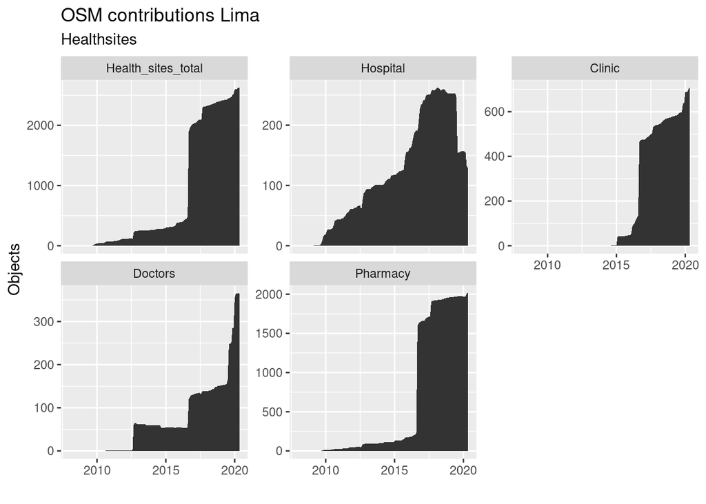

```r
ggplot(resHealthTs_long, mapping=aes(x=timestamp, y=count)) + geom_area() + facet_wrap(facets = vars(type), scales="free_y") + xlab("") + ylab("Objects") + labs(title = "OSM contributions Lima", subtitle = "Healthsites")
```

Similar to hoghways a part of the contributions probably originates from an import that affectes all classes but most dominately pharmacies. The drop in hospitals might originate from a quality controll operation that resulted in an reclassification of hospitals to clinics or doctors.

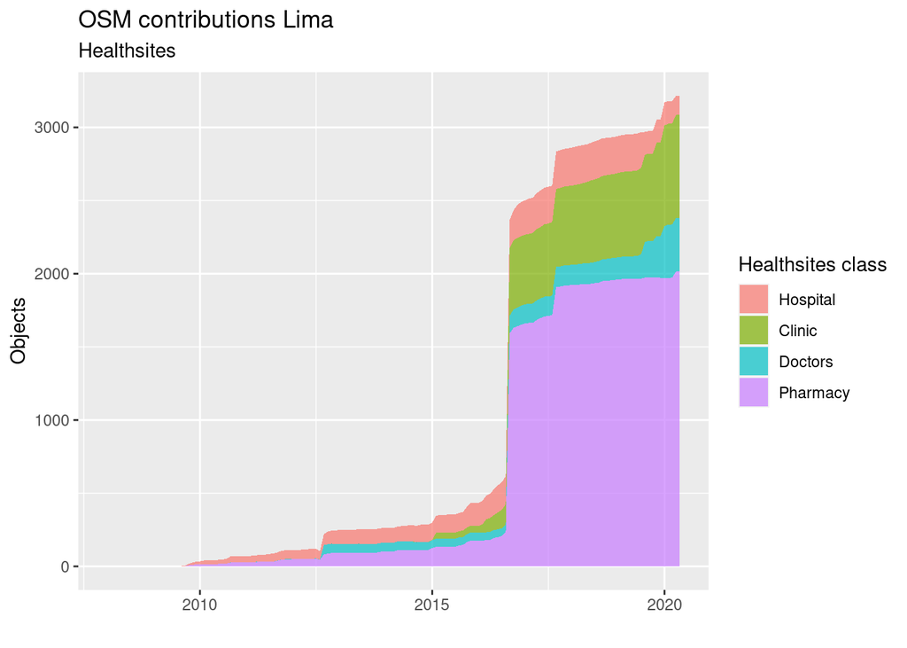

```r
resHealthTs_long %>%
  filter(type != "Health_sites_total") %>%
  ggplot( mapping=aes(x=timestamp, y=count, fill=type)) +
  geom_area(position="stack", show.legend = TRUE, alpha=.7) +
  scale_fill_discrete(name = "Healthsites class",
                      labels = c("Hospital", "Clinic", "Doctors", "Pharmacy")) +
  xlab("") + ylab("Objects") +
  labs(title = "OSM contributions Lima", subtitle = "Healthsites")
```

## 2.2 Number of active users

The number of active users is an important indicator to judge on saturation curves. A saturation in contributions might have been reached because: * everything of that specific category has been already mapped * there are no mappers around anymore

If a sufficient number of mappers is around one might take this as an indication that saturation really implies high level of completeness.

We can use the ohmsome API to query the number of active users as well. The need a different endpoint (c.f. https://docs.ohsome.org/ohsome-api/v1/endpoints.html#users-aggregation-endpoints) and we need to be aware that the data returned are different: we get ther number of users active (at least one edit) between a start and an end (a time period).

```r
resActiveUsers <- getOsomeStat(uri = "https://api.ohsome.org/v1/users/count/", bboxes = limaBboxStr,  time = theTimeUser, valueFieldName = "countUsers")
```

```r
head(resActiveUsers)
```

```
## # A tibble: 6 x 3
##   fromTimestamp       toTimestamp         countUsers
##   <dttm>              <dttm>                   <dbl>
## 1 2007-12-01 00:00:00 2008-01-01 00:00:00          4
## 2 2008-01-01 00:00:00 2008-02-01 00:00:00          1
## 3 2008-02-01 00:00:00 2008-03-01 00:00:00          1
## 4 2008-03-01 00:00:00 2008-04-01 00:00:00          3
## 5 2008-04-01 00:00:00 2008-05-01 00:00:00          2
## 6 2008-05-01 00:00:00 2008-06-01 00:00:00          2
```

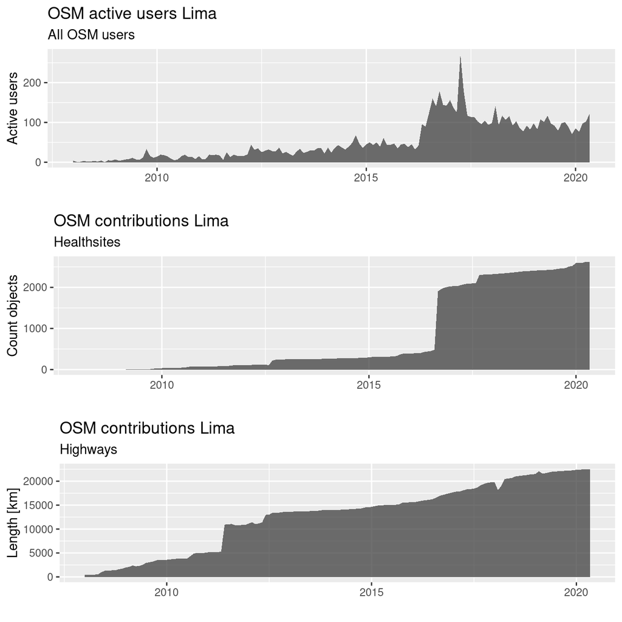

```r
p1 <- resActiveUsers %>%
  ggplot(mapping=aes(x=toTimestamp, y=countUsers)) +
  geom_area(alpha=.7) +
  xlab("") + ylab("Active users") +
  labs(title = "OSM active users Lima", subtitle = "All OSM users")

p2 <- resHealthTs_long %>%
  filter(type == "Health_sites_total") %>%
  ggplot( mapping=aes(x=timestamp, y=count)) +
  geom_area(position="stack", show.legend = FALSE, alpha=.7) +
  xlab("") + ylab("Count objects") +
  labs(title = "OSM contributions Lima", subtitle = "Healthsites")

p3 <- resHighwayTs_long %>%
  filter(type == "total_highway_length") %>%
  ggplot( mapping=aes(x=timestamp, y=length)) +
  geom_area(position="stack", show.legend = FALSE, alpha=.7) +
  xlab("") + ylab("Length [km]") +
  labs(title = "OSM contributions Lima", subtitle = "Highways")

ggarrange(p1, p2, p3, ncol=1)
```

What we can spot is that: - the jumps in contributions for health sites and for highways don’t co-occur at the same time - the jumps in constributions are not reflected by an increase in user activity - hinting even more for import events - the strong peak in user activity has not led to a remarkable increase in highway or health sites contributions

# 3 Exercise

Redo the analysis for building=*.